# How Did Covid Affect Seattle Housing Price

Yuan Zhou

May 26, 2023

# Introduction

After going to school in Seattle for 4 years, I found Seattle to have an very unique personality. It has a balanced blend of metropolitan and nature; It’s surrounded by the ocean and mountains; It has traditions while the people are also extremely forward thinking.

[figure not shown]

At the same time, Seattle is group zero for covid in the US, as it has seen the first U.S covid case. On the individual scale, everyone’s life has changed since then. On the scale of the world, it has slowed down the global’s economy for years. Housing prices have always been somewhat of an indicator of the state of the economy, since the desire of buying a house is relateable to the vast majority. Therefore, the aim of this project is to perform forecast as if covid did not happen and study how covid affected housing prices in Seattle.

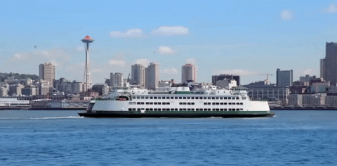

Downtown Seattle

```
## [1] 897 331
```

```
## [1] "data.frame"
```

# Initial Analysis

```
## [1] 361321.9
```

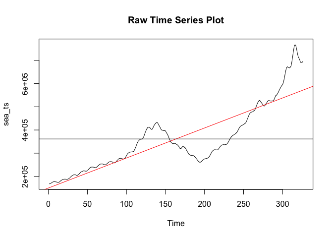

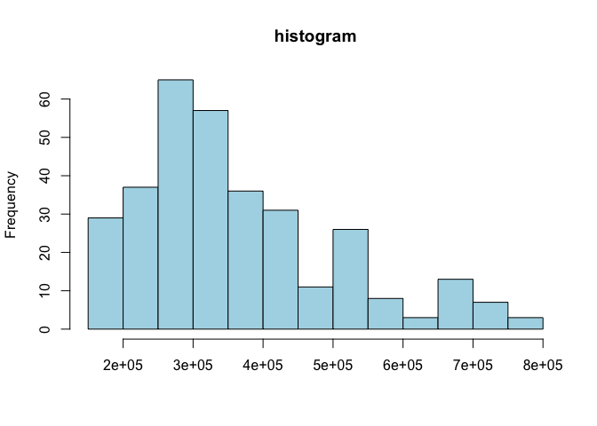

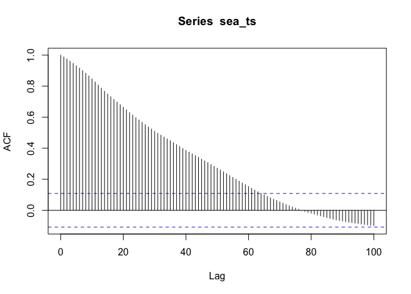

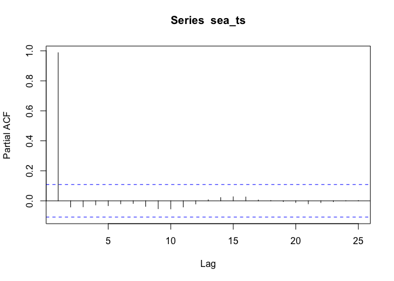

```
## [1] 19973225295
```

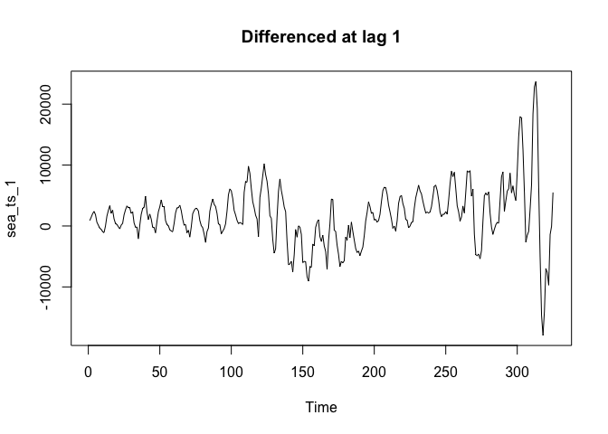

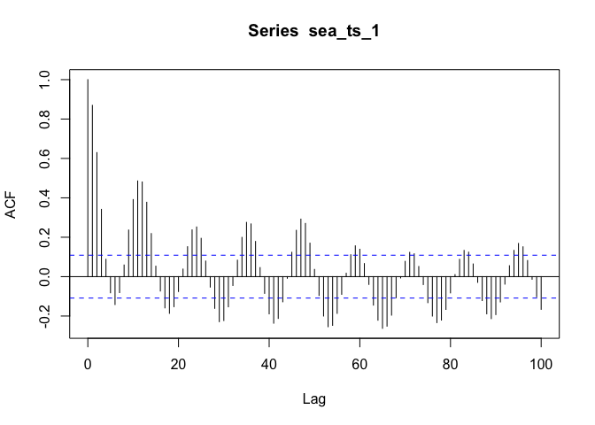

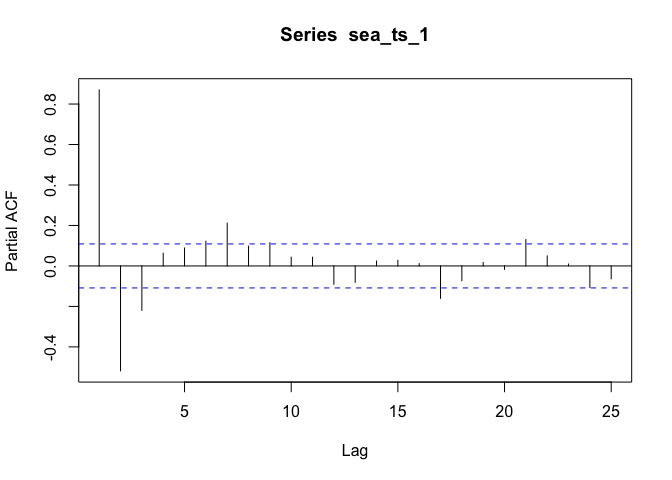

```
## [1] 23905120
```

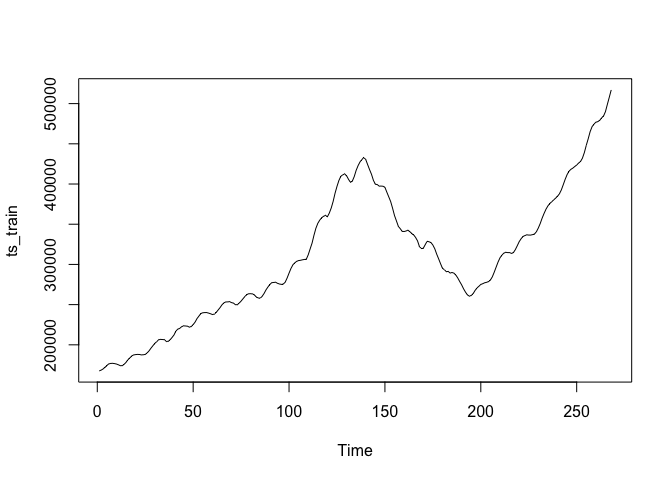

```r
ts_validation = sea_ts[c(268:280)]
ts_train = sea_ts[c(1:268)]
ts.plot(ts_train)
```

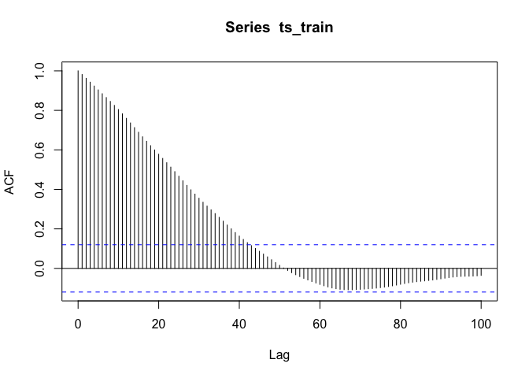

```r
acf(ts_train, lag.max = 100)
```

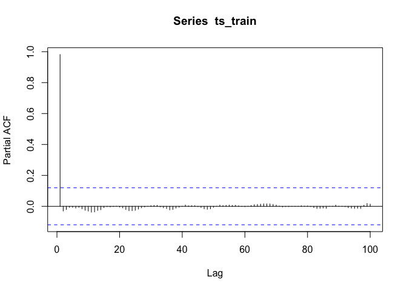

```r
pacf(ts_train, lag.max = 100)
```

```r
bcTransform <- boxcox(ts_train ~ as.numeric(1: length(ts_train)))
```

[figure not shown]

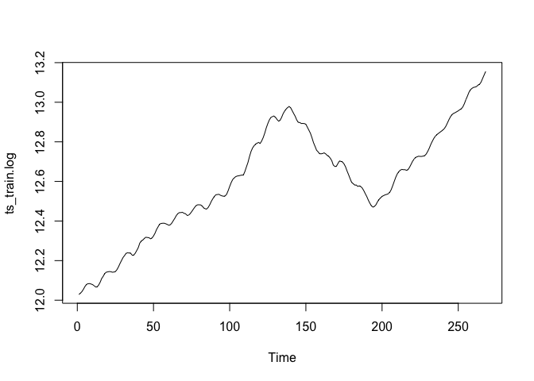

```r
lambda=bcTransform$x[which(bcTransform$y == max(bcTransform$y))]

# It's going to be a log transformation
ts_train.log <- log(ts_train)

ts.plot(ts_train.log)
```

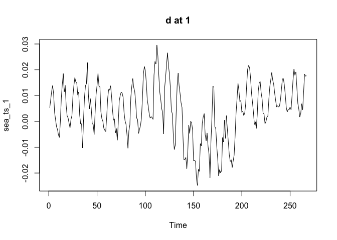

```r
sea_ts_1 <- diff(ts_train.log, lag = 1)
ts.plot(sea_ts_1)
title(main = "d at 1")
```

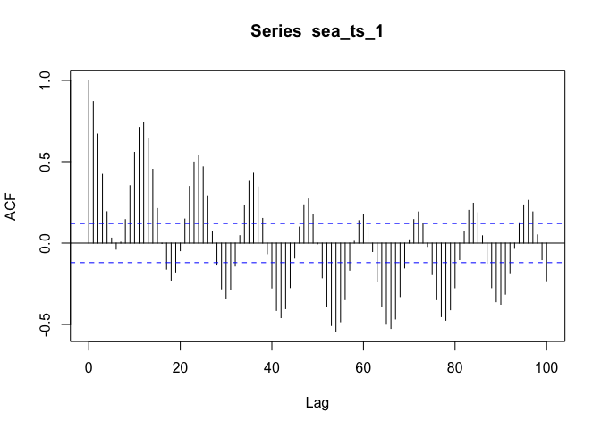

```r
acf(sea_ts_1, lag.max = 100)
```

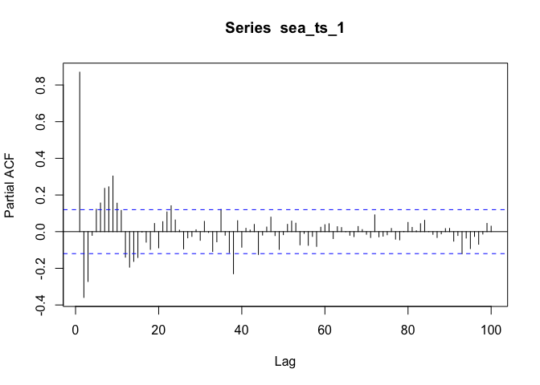

```r
pacf(sea_ts_1, lag.max = 100)
```

```r
var(sea_ts_1)
```

```
## [1] 0.0001118281
```

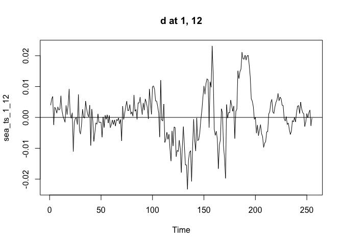

```r
sea_ts_1_12 <- diff(sea_ts_1, lag = 12)
ts.plot(sea_ts_1_12)
abline(h = 0)
title(main = "d at 1, 12")
```

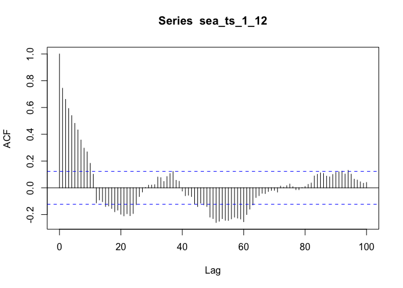

```r
acf(sea_ts_1_12, lag.max = 100)
```

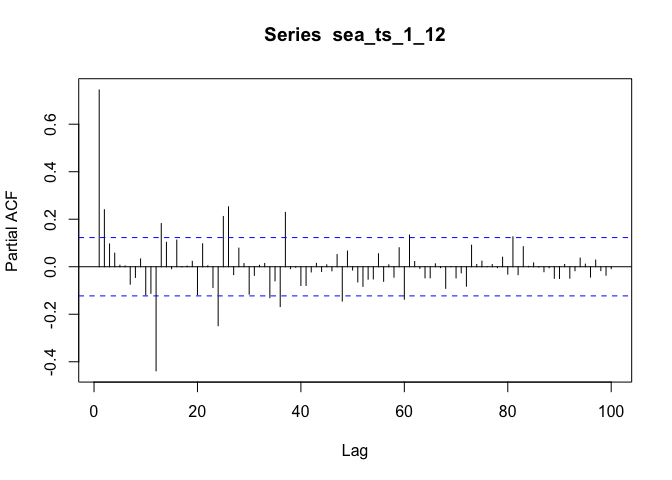

```r
pacf(sea_ts_1_12, lag.max = 100)
```

```r
var(sea_ts_1_12)
```

```
## [1] 5.473797e-05
```

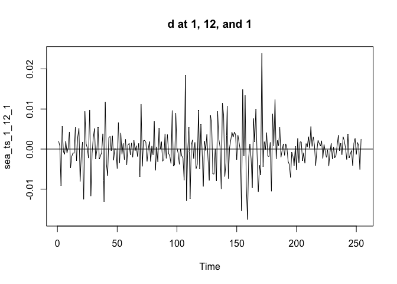

```r
sea_ts_1_12_1 <- diff(sea_ts_1_12, lag = 1)
ts.plot(sea_ts_1_12_1)
abline(h = 0)
title(main = "d at 1, 12, and 1")
```

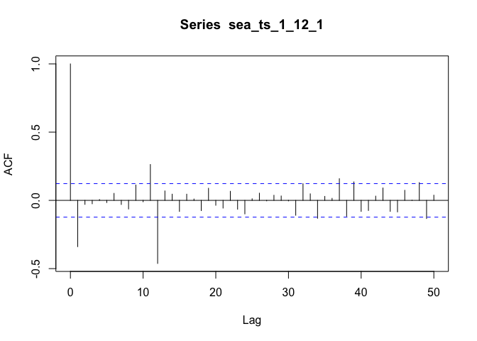

```r
acf(sea_ts_1_12_1, lag.max = 50)
```

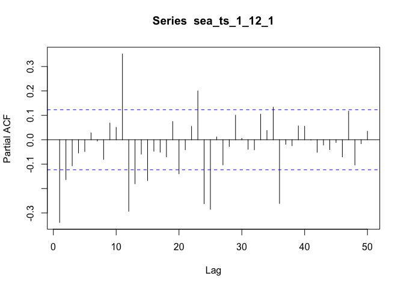

```r
pacf(sea_ts_1_12_1, lag.max = 50)
```

```r
var(sea_ts_1_12_1)
```

```
## [1] 2.80657e-05
```

MA Q = 1,q = 1

SARIMA(0,2,1)(0,1,1) s =12

p = 2